# Practical Power Analysis in R

Metin Bulus & Sebastian Jentschke

2026-09-28

Install and load pwrss R package:

```r
install.packages("pwrss")
library(pwrss)
```

If you find the package and related material useful please cite as:

Bulus, M., & Jentschke, S. (2026). pwrss: Statistical Power, Sample Size, and Detectable Effect Calculations. R package version 1.2.0. https://doi.org/10.32614/CRAN.package.pwrss

**Acknowledgments**

This open-source project has benefited from users who have taken the time to report typos and identify bugs. We would like to acknowledge those who have helped improve the accuracy and quality of the project by reporting these issues. If we have missed anyone who has provided similar feedback, please let me know.

Error reports from (alphabetic order):  
Adrian Olszewski (bug report); Catherine (Kate) Crespi (bug report); dpnichols811 (GitHub profile, bug report); Fred Oswald (typo report); Jarrod Hadfield (bug report); Leszek Gawarecki (typo report); liegepr (GitHub profile, bug report); Roland Thijs (typo report); Wes Cummings (reporting a bug and helping to fix it)

Please send any bug reports, feedback, or questions to bulusmetin [at] gmail.com

# 1 Generic

These generic functions compute and return statistical power with the option to generate Type I and Type II error plots when test statistics and degrees of freedom are available. Users can input test statistics manually, valuable for custom designs outside the {pwrss} package’s scope, or extract them from statistical software output.

## 1.1 T-Test

### 1.1.1 Post-Hoc

**Example**: The `mtcars` dataset in R that contains information about 32 car models from the 1974 issue of Motor Trend magazine and includes various performance and design attributes for each vehicle. The variables of interest:

- `mpg` : Miles per gallon
- `hp` : Gross horsepower
- `wt` : Weight of the car (in 1000 lbs unit)

We aim to estimate the extent to which a one-unit increase in gross horsepower is associated with miles per gallon, while controlling for vehicle weight. What is the post-hoc power given the observed test statistic?

```r
data(mtcars)

model <- lm(mpg ~ hp + wt, data = mtcars)
summary(model)
```

```
#>
#> Call:
#> lm(formula = mpg ~ hp + wt, data = mtcars)
#>
#> Residuals:
#>    Min     1Q Median     3Q    Max
#> -3.941 -1.600 -0.182  1.050  5.854
#>
#> Coefficients:
#>             Estimate Std. Error t value Pr(>|t|)
#> (Intercept) 37.22727    1.59879  23.285  < 2e-16 ***
#> hp          -0.03177    0.00903  -3.519  0.00145 **
#> wt          -3.87783    0.63273  -6.129 1.12e-06 ***
#> ---
#> Signif. codes:  0 '***' 0.001 '**' 0.01 '*' 0.05 '.' 0.1 ' ' 1
#>
#> Residual standard error: 2.593 on 29 degrees of freedom
#> Multiple R-squared:  0.8268, Adjusted R-squared:  0.8148
#> F-statistic: 69.21 on 2 and 29 DF,  p-value: 9.109e-12
```

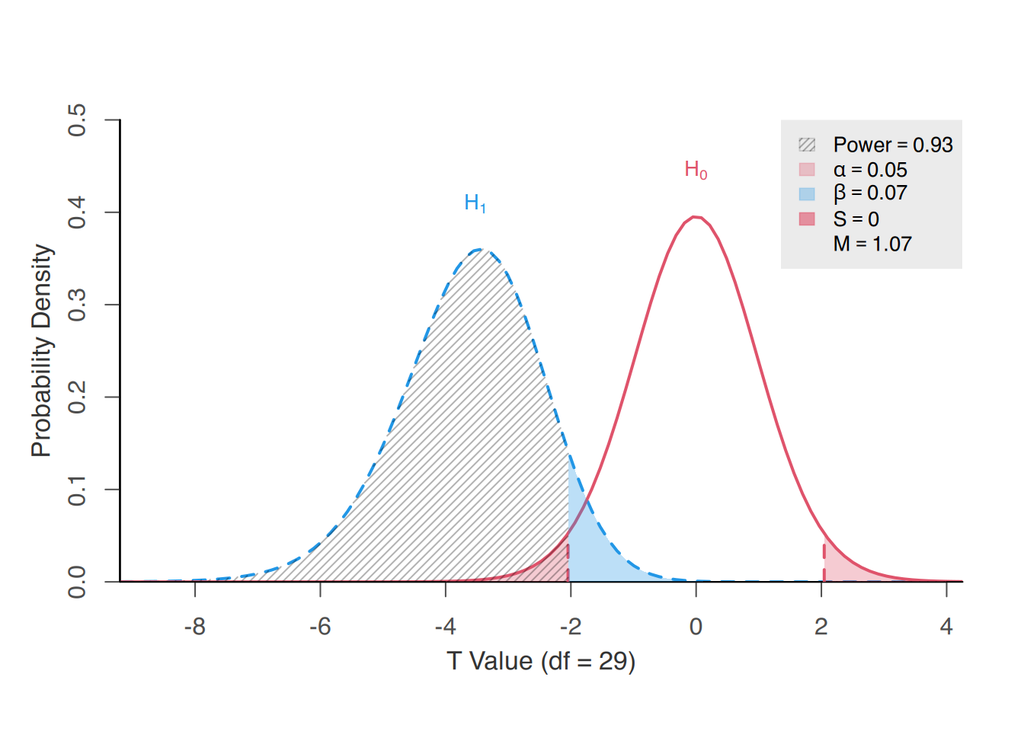

```
#> +--------------------------------------------------+
#> |                POWER CALCULATION                 |
#> +--------------------------------------------------+
#>
#> Generic t-Test
#>
#> ----------------------------------------------------
#> Hypotheses
#> ----------------------------------------------------
#>   H0 (Null)        : lambda  = null.lambda
#>   H1 (Alternative) : lambda != null.lambda
#>
#> ----------------------------------------------------
#> Results
#> ----------------------------------------------------
#>   Target NCP (lambda)  = -3.519 (vs. null.lambda = 0)
#>   Degrees of Freedom   = 29
#>   Type 1 Error (alpha) = 0.050
#>   Type 2 Error (beta)  = 0.075
#>   Statistical Power    = 0.925  <<
```

```r
power.t.test(ncp = -3.519, # t-value for hp variable
             df = 29,      # residual degrees of freedom
             alpha = 0.05, # type 1 error rate
             alternative = "two.sided",
             plot = TRUE)
```

**Report**: The post-hoc power analysis showed that a sample of 32 cars had a 0.925 chance of detecting the observed relationship between horsepower and miles per gallon, if such a relationship exists. The analysis was conducted using an $\alpha$ level of 0.05.

However, post-hoc power has limited practical value. Given such a sample size, minimum detectable test statistics (MDTS) is -2.899. The estimated value of -3.519 is much larger than the MDTS in absolute value. The Type M error of 1.16 for the MDTS suggests that the estimated effect is subject to only modest magnitude inflation and is therefore unlikely to be explained primarily by effect-size exaggeration.

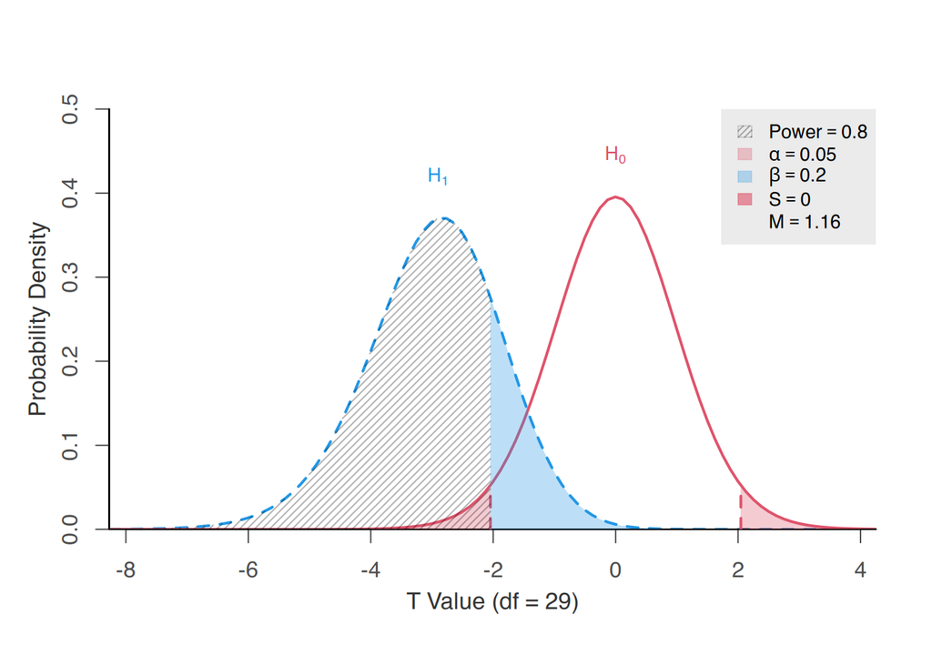

```
#> +--------------------------------------------------+
#> |       MINIMUM DETECTABLE NCP CALCULATION         |
#> +--------------------------------------------------+
#>
#> Generic t-Test
#>
#> ----------------------------------------------------
#> Hypotheses
#> ----------------------------------------------------
#>   H0 (Null)        : lambda  = null.lambda
#>   H1 (Alternative) : lambda != null.lambda
#>
#> ----------------------------------------------------
#> Results
#> ----------------------------------------------------
#>   Target NCP (lambda)  = -2.899 (vs. null.lambda = 0)  <<
#>   Degrees of Freedom   = 29
#>   Type 1 Error (alpha) = 0.050
#>   Type 2 Error (beta)  = 0.200
#>   Statistical Power    = 0.800
```

```r
power.t.test(ncp = NULL,     # calculate this
             req.sign = "-", # direction of the test statistics
             df = 29,        # residual degrees of freedom
             alpha = 0.05,   # type 1 error rate
             power = 0.80,
             alternative = "two.sided",
             plot = TRUE)
```

### 1.1.2 User-Defined Design

Power calculation is not readily available for non-equivalent pre-test vs. post-test control-group-designs but the formula is already known. The approximate standard error is

$$SE = \sqrt{\frac{1 - R^2}{p(1 - p)n(1 -
R^2_{TX})}}$$

with $df = n - g - 2$ where

- $R^2$ : Explanatory power of covariates
- $R^2_{TX}$ : Squared point-biserial correlation between treatment indicator and pre-test
- $p$ : Group allocation rate
- $n$ : Total sample size
- $g$ : Number of covariates

For details please see ([Bulus](https://dergipark.org.tr/tr/download/article-file/1783497), 2021, p. 52; [Oakes and Feldman](https://doi.org/10.1177%2F0193841X0102500101), 2001, p. 15).

**Example**: A team of educational psychologists implements a mindfulness-based stress-reduction program in 6th-grade classrooms at one middle school, while 6th-grade classrooms at another school continue with their usual homeroom activities (the conventional approach). They want to determine whether the new program yields greater improvements in emotional regulation by comparing students in the intervention school with those in the control school. All students complete a standardized emotional-regulation inventory at both the start and the end of the semester.

A superiority test will be conducted to assess whether improvements in the intervention school exceed those in the control school by a meaningful margin. The researcher considers a medium effect relevant and sufficient support for potential scale-up (`d = 0.50`) and defines the superiority margin as 0.10 - that is, the mindfulness program will be considered superior to the conventional program if the `d - null.d` is at least 0.10.

Assume there are two classrooms in each school, each classroom has 30 students, the pre-test accounts for 50% of the variance in post-test scores, and the squared point-biserial correlation between group membership and emotional regulation scores is 0.10. What is the power to detect superiority under these criteria?

```r
# define parameters
d <- 0.50           # effect size under alternative
null.d <- 0         # effect size under null
margin <- 0.10      # smallest meaningful diff between d and null.d

p <- 0.50           # proportion of subjects in the intervention school
n <- 120            # total sample size
g <- 1              # number of covariates
r.squared <- 0.50   # explanatory power of covariates
rtx.squared <- 0.10 # squared point-biserial cor between trt dummy and outcome

# calculate the standard error
std.error <- sqrt((1 - r.squared) / (p * (1 - p) * n * (1 - rtx.squared)))

# calculate non-centrality parameters
ncp <- (d - null.d) / std.error
null.ncp <- margin / std.error

# calculate power
power.t.test(ncp = ncp,
             null.ncp = null.ncp,
             df = n - g - 2,
             alpha = 0.05,
             alternative = "one.sided",
             plot = FALSE)
```

```
#> +--------------------------------------------------+
#> |                POWER CALCULATION                 |
#> +--------------------------------------------------+
#>
#> Generic t-Test
#>
#> ----------------------------------------------------
#> Hypotheses
#> ----------------------------------------------------
#>   H0 (Null)        : lambda <= null.lambda
#>   H1 (Alternative) : lambda  > null.lambda
#>
#> ----------------------------------------------------
#> Results
#> ----------------------------------------------------
#>   Target NCP (lambda)  = 3.674 (vs. null.lambda = 0.735)
#>   Degrees of Freedom   = 117
#>   Type 1 Error (alpha) = 0.050
#>   Type 2 Error (beta)  = 0.104
#>   Statistical Power    = 0.896  <<
```

**Report**: A power analysis was conducted to assess whether a sample of 120 students would be sufficient to detect the effect of a mindfulness intervention on emotional regulation. The analysis targeted a moderate effect size (d = 0.50) with a superiority margin of 0.10, using a one-tailed test at $\alpha$ = 0.05. This design yielded an estimated power of 0.90, indicating adequate sensitivity to detect the intervention effect.

## 1.2 Z-Test

### 1.2.1 Post-Hoc

**Example**: The `warpbreaks` dataset in R contains data from an experiment on the number of warp breaks per loom in a fixed length of yarn. It includes information on the type of wool and tension level used during weaving. The dataset is often used to illustrate count data modeling. The variables of interest:

- `breaks`: Number of warp breaks
- `wool`: Type of wool (factor with levels A and B)
- `tension`: Tension applied to the yarn (factor with levels Low, Medium, High)

We aim to estimate the extent to which the type of wool and the level of tension are associated with the number of warp breaks using a Poisson regression model. What is the post-hoc power given the observed test statistic for Wool B?

```r
data(warpbreaks)

model <- glm(breaks ~ wool + tension, data = warpbreaks,
             family = poisson(link = "log"))
summary(model)
```

```
#>
#> Call:
#> glm(formula = breaks ~ wool + tension, family = poisson(link = "log"),
#>     data = warpbreaks)
#>
#> Coefficients:
#>             Estimate Std. Error z value Pr(>|z|)
#> (Intercept)  3.69196    0.04541  81.302  < 2e-16 ***
#> woolB       -0.20599    0.05157  -3.994 6.49e-05 ***
#> tensionM    -0.32132    0.06027  -5.332 9.73e-08 ***
#> tensionH    -0.51849    0.06396  -8.107 5.21e-16 ***
#> ---
#> Signif. codes:  0 '***' 0.001 '**' 0.01 '*' 0.05 '.' 0.1 ' ' 1
#>
#> (Dispersion parameter for poisson family taken to be 1)
#>
#>     Null deviance: 297.37  on 53  degrees of freedom
#> Residual deviance: 210.39  on 50  degrees of freedom
#> AIC: 493.06
#>
#> Number of Fisher Scoring iterations: 4
```

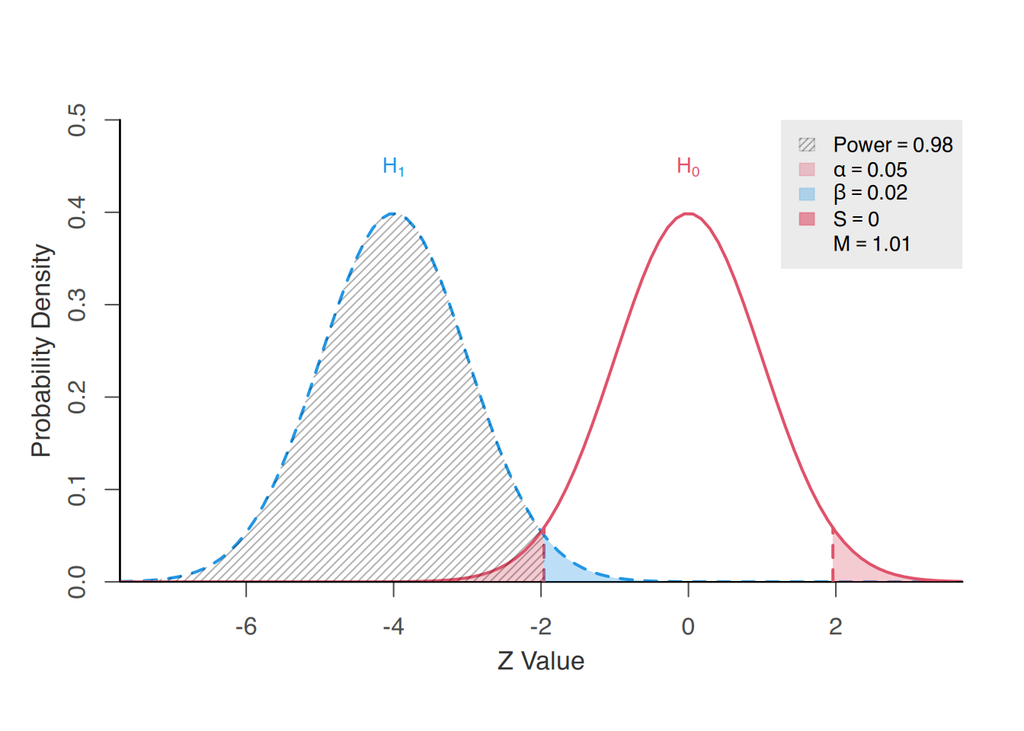

```
#> +--------------------------------------------------+
#> |                POWER CALCULATION                 |
#> +--------------------------------------------------+
#>
#> Generic z-Test
#>
#> ----------------------------------------------------
#> Hypotheses
#> ----------------------------------------------------
#>   H0 (Null)        : mean  = null.mean
#>   H1 (Alternative) : mean != null.mean
#>
#> ----------------------------------------------------
#> Results
#> ----------------------------------------------------
#>   Target NCP (mean)    = -3.994 (vs. null.mean = 0)
#>   Type 1 Error (alpha) = 0.050
#>   Type 2 Error (beta)  = 0.021
#>   Statistical Power    = 0.979  <<
```

```r
power.z.test(mean = -3.994, # z-value for wool B
             alpha = 0.05,  # type 1 error rate
             alternative = "two.sided",
             plot = TRUE)
```

**Report**: The post-hoc power analysis showed that a sample of 54 trials had a 0.979 chance of detecting the observed relationship between Wool B and number of warp breaks, if such a relationship exists. The analysis was conducted using an $\alpha$ level of 0.05.

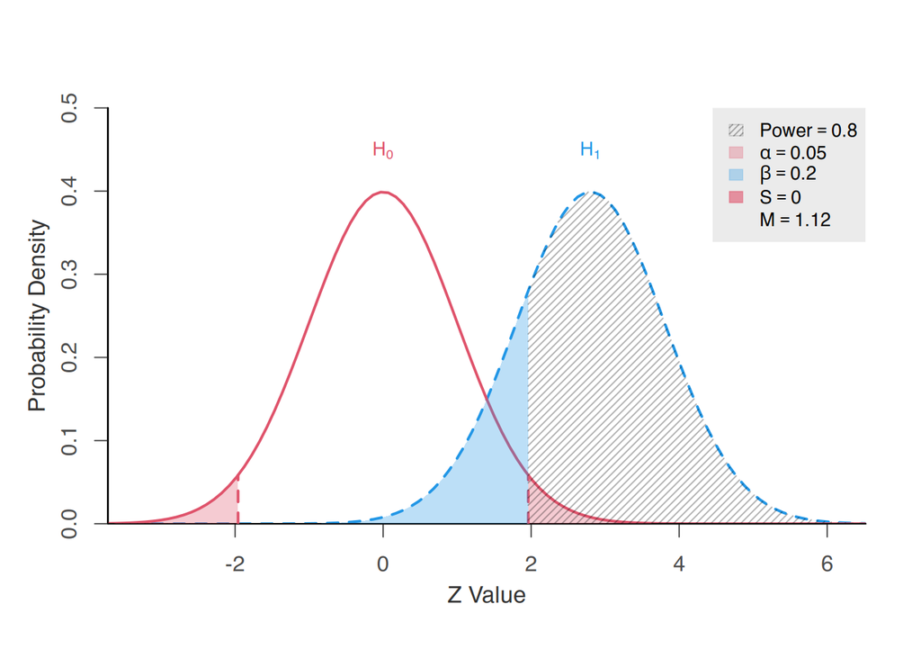

```
#> +--------------------------------------------------+
#> |       MINIMUM DETECTABLE NCP CALCULATION         |
#> +--------------------------------------------------+
#>
#> Generic z-Test
#>
#> ----------------------------------------------------
#> Hypotheses
#> ----------------------------------------------------
#>   H0 (Null)        : mean  = null.mean
#>   H1 (Alternative) : mean != null.mean
#>
#> ----------------------------------------------------
#> Results
#> ----------------------------------------------------
#>   Target NCP (mean)    = 2.802 (vs. null.mean = 0)  <<
#>   Type 1 Error (alpha) = 0.050
#>   Type 2 Error (beta)  = 0.200
#>   Statistical Power    = 0.800
```

```r
power.z.test(mean = NULL,   # calculate this
             alpha = 0.05,  # type 1 error rate
             power = 0.80,
             alternative = "two.sided",
             plot = TRUE)
```

### 1.2.2 User Defined Design

Power calculation is not readily available for Spearman’s $\rho$ rank correlation but the formula is already known. The approximate standard error for the Fisher’s Z-transformed correlation coefficient is

$$SE = \sqrt{\frac{1.06}{n -
3}}$$

where $n$ is the sample size. For details please see ([Fieller, Hartley, and Pearson](https://doi.org/10.1093/biomet/44.3-4.470), 1957, p. 472).

**Example**: A team of school counselors want to examine whether there is a relationship between students’ class rank (1st, 2nd, 3rd, etc.) and their self-reported academic stress levels, measured on a 10-point scale (1 = no stress, 10 = extreme stress). Since class rank is an ordinal variable (lower ranks mean higher academic standing) and the stress scale is subjective and potentially not interval-scaled, the counselor uses Spearman’s rank-order correlation (Spearman’s $\rho$) to assess whether higher-ranking students tend to report lower or higher levels of stress.

Researchers hypothesize that students with higher class ranks (i.e., lower rank numbers) report lower stress levels. They plan to recruit 100 students, interested in detecting a Spearman’s $\rho$ as small as 0.30, and will use a two-tailed test with an $\alpha$ level of 0.05. What is the power under these criteria?

```r
# define parameters
rs <- 0.30   # spearman rho rank cor under alternative
null.rs <- 0 # spearman rho rank cor under null
n <- 100     # sample size

# apply Fisher's Z transformation
z.rs <- cor.to.z(rs)$z
```

```
#>         z       rho
#> 0.3095196 0.3000000
```

```r
z.null.rs <- cor.to.z(null.rs)$z
```

```
#>   z rho
#>   0   0
```

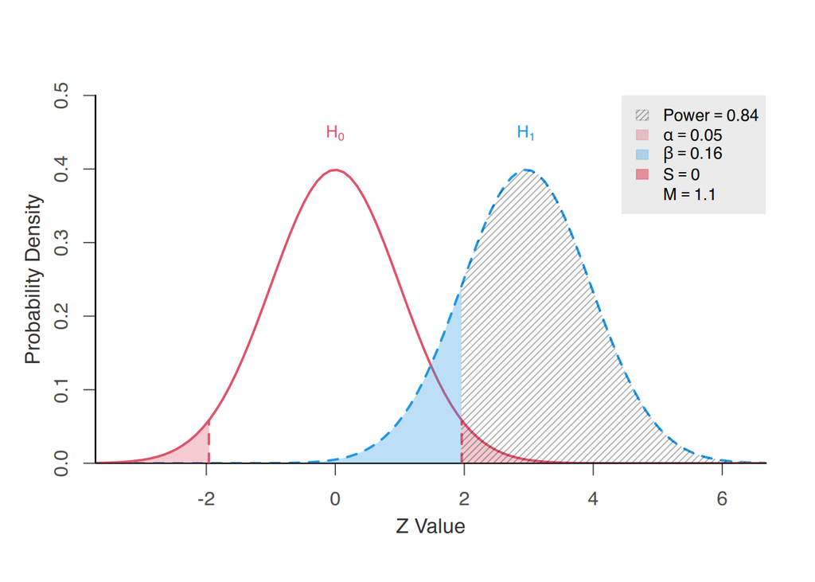

```
#> +--------------------------------------------------+
#> |                POWER CALCULATION                 |
#> +--------------------------------------------------+
#>
#> Generic z-Test
#>
#> ----------------------------------------------------
#> Hypotheses
#> ----------------------------------------------------
#>   H0 (Null)        : mean  = null.mean
#>   H1 (Alternative) : mean != null.mean
#>
#> ----------------------------------------------------
#> Results
#> ----------------------------------------------------
#>   Target NCP (mean)    = 2.961 (vs. null.mean = 0)
#>   Type 1 Error (alpha) = 0.050
#>   Type 2 Error (beta)  = 0.158
#>   Statistical Power    = 0.842  <<
```

```r
# calculate the standard error
z.std.error <- sqrt(1.06 / (n - 3))

# calculate the non-centrality parameter
ncp <- (z.rs - z.null.rs) / z.std.error

# calculate power
power.z.test(mean = ncp,
             alpha = 0.05,
             alternative = "two.sided",
             plot = TRUE)
```

**Report**: A power analysis was conducted to assess whether 100 students are sufficient to detect association between students’ class rank and their self-reported academic stress levels. The analysis targeted a moderate Spearman’s $\rho$ of 0.30, a two-tailed test with $\alpha$ = 0.05. This configuration yielded an estimated power of 0.84, indicating sufficient sensitivity to detect the hypothesized association.

## 1.3 F-Test

### 1.3.1 Post-Hoc

**Example**: The `trees` dataset in R contains measurements of the volume, height, and girth (diameter) of 31 black cherry trees. The variables of interest:

- `Girth`: Diameter of the tree (in inches)
- `Height`: Height of the tree (in feet)

We aim to estimate the extent to which the tree height is associated with the tree girth. What is the post-hoc power given the observed test statistic?

```r
data(trees)

# model <- aov(Girth ~ Height, data = trees)
model <- lm(Girth ~ Height, data = trees)
summary(model)
```

```
#>
#> Call:
#> lm(formula = Girth ~ Height, data = trees)
#>
#> Residuals:
#>     Min      1Q  Median      3Q     Max
#> -4.2386 -1.9205 -0.0714  2.7450  4.5384
#>
#> Coefficients:
#>             Estimate Std. Error t value Pr(>|t|)
#> (Intercept) -6.18839    5.96020  -1.038  0.30772
#> Height       0.25575    0.07816   3.272  0.00276 **
#> ---
#> Signif. codes:  0 '***' 0.001 '**' 0.01 '*' 0.05 '.' 0.1 ' ' 1
#>
#> Residual standard error: 2.728 on 29 degrees of freedom
#> Multiple R-squared:  0.2697, Adjusted R-squared:  0.2445
#> F-statistic: 10.71 on 1 and 29 DF,  p-value: 0.002758
```

```r
power.f.test(ncp = 10.71,  # non-centrality under alternative
             df1 = 1,      # numerator degrees of freedom
             df2 = 29,     # denominator degrees of freedom
             alpha = 0.05, # type 1 error rate
             plot = FALSE)
```

```
#> +--------------------------------------------------+
#> |                POWER CALCULATION                 |
#> +--------------------------------------------------+
#>
#> Generic F-Test
#>
#> ----------------------------------------------------
#> Hypotheses
#> ----------------------------------------------------
#>   H0 (Null)        : lambda = 0
#>   H1 (Alternative) : lambda > 0
#>
#> ----------------------------------------------------
#> Results
#> ----------------------------------------------------
#>   Target NCP (lambda)  = 10.710 (vs. null.lambda = 0)
#>   Presumed Sample S.   = 31
#>   Type 1 Error (alpha) = 0.050
#>   Type 2 Error (beta)  = 0.115
#>   Statistical Power    = 0.885  <<
```

**Report**: The post-hoc power analysis showed that a sample of 31 trees had a 0.885 chance of detecting the observed relationship between tree height and girth, if such a relationship exists in the population. The analysis was conducted using an $\alpha$ level of 0.05.

Given such a sample size and research design, minimum detectable test statistics (MDTS) is 8.403. The estimated value of 10.71 is much larger than the MDTS.

```r
power.f.test(ncp = NULL,   # calculate this
             df1 = 1,      # numerator degrees of freedom
             df2 = 29,     # denominator degrees of freedom
             power = 0.80,
             alpha = 0.05, # type 1 error rate
             plot = FALSE)
```

```
#> +--------------------------------------------------+
#> |       MINIMUM DETECTABLE NCP CALCULATION         |
#> +--------------------------------------------------+
#>
#> Generic F-Test
#>
#> ----------------------------------------------------
#> Hypotheses
#> ----------------------------------------------------
#>   H0 (Null)        : lambda = 0
#>   H1 (Alternative) : lambda > 0
#>
#> ----------------------------------------------------
#> Results
#> ----------------------------------------------------
#>   Target NCP (lambda)  = 8.403 (vs. null.lambda = 0)  <<
#>   Presumed Sample S.   = 31
#>   Type 1 Error (alpha) = 0.050
#>   Type 2 Error (beta)  = 0.200
#>   Statistical Power    = 0.800
```

## 1.4 Chi-square Test

### 1.4.1 Post-Hoc 1

**Example**: The `HairEyeColor` dataset in R contains data from a survey of 592 students, recording the joint distribution of hair color, eye color, and gender. It is stored as a three-dimensional contingency table, with counts representing the number of individuals in each category. The variables of interest:

- `Hair`: Hair color (e.g., Black, Brown, Blond, Red)
- `Eye`: Eye color (e.g., Brown, Blue, Hazel, Green)

We aim to examine the association between hair color and eye color. What is the post-hoc power given the observed test statistic from a chi-squared test of independence?

```r
data(HairEyeColor)

table <- margin.table(HairEyeColor, c(1, 2))
print(table)
```

```
#>        Eye
#> Hair    Brown Blue Hazel Green
#>   Black    68   20    15     5
#>   Brown   119   84    54    29
#>   Red      26   17    14    14
#>   Blond     7   94    10    16
```

```r
chisq.test(table)
```

```
#>
#>  Pearson's Chi-squared test
#>
#> data:  table
#> X-squared = 138.29, df = 9, p-value < 2.2e-16
```

```r
power.chisq.test(ncp = 138.29, # X-squared
                 df = 9,       # degrees of freedom
                 alpha = 0.05, # type 1 error rate
                 plot = FALSE)
```

```
#> +--------------------------------------------------+
#> |                POWER CALCULATION                 |
#> +--------------------------------------------------+
#>
#> Generic Chi-square Test
#>
#> ----------------------------------------------------
#> Hypotheses
#> ----------------------------------------------------
#>   H0 (Null)        : lambda = null.lambda
#>   H1 (Alternative) : lambda > null.lambda
#>
#> ----------------------------------------------------
#> Results
#> ----------------------------------------------------
#>   Target NCP (lambda)  = 138.290 (vs. null.lambda = 0)
#>   Degrees of Freedom   = 9
#>   Type 1 Error (alpha) = 0.050
#>   Type 2 Error (beta)  = 0.000
#>   Statistical Power    = 1.000  <<
```

**Report**: The post-hoc power analysis showed that a sample of 592 individuals had a 1.00 chance of detecting the observed relationship between hair and eye color, if such a relationship exists in the population. The analysis was conducted using an $\alpha$ level of 0.05.

Given such a sample size and research design, minimum detectable test statistics (MDTS) is 15.65. The estimated value of 138.29 is much larger than the MDTS.

```r
power.chisq.test(ncp = NULL,    # calculate this
                 df = 9,        # degrees of freedom
                 power = 0.80,
                 alpha = 0.05,  # type 1 error rate
                 plot = FALSE)
```

```
#> +--------------------------------------------------+
#> |       MINIMUM DETECTABLE NCP CALCULATION         |
#> +--------------------------------------------------+
#>
#> Generic Chi-square Test
#>
#> ----------------------------------------------------
#> Hypotheses
#> ----------------------------------------------------
#>   H0 (Null)        : lambda = null.lambda
#>   H1 (Alternative) : lambda > null.lambda
#>
#> ----------------------------------------------------
#> Results
#> ----------------------------------------------------
#>   Target NCP (lambda)  = 15.650 (vs. null.lambda = 0)  <<
#>   Degrees of Freedom   = 9
#>   Type 1 Error (alpha) = 0.050
#>   Type 2 Error (beta)  = 0.200
#>   Statistical Power    = 0.800
```

### 1.4.2 Post-Hoc 2

**Example**: The `infert` dataset in R contains data from a study on infertility in women, examining the relationship between reproductive history and infertility status. It includes demographic and clinical information on 248 women. The variables of interest:

- `case`: Infertility status (1 = infertile, 0 = fertile)
- `age`: Age of woman in years
- `parity`: Number of prior full-term pregnancies
- `induced`: Number of induced abortions
- `spontaneous`: Number of spontaneous abortions

We aim to evaluate whether the number of induced abortions contributes to the prediction of infertility status, beyond the effects of age, parity, and spontaneous abortions, using a logistic regression framework. What is the post-hoc power given the observed deviance difference between the full and reduced models?

```r
data(infert)

fit.reduced <- glm(case ~ age + parity + spontaneous,
                   data = infert,
                   family = binomial)

fit.full <- glm(case ~ age + parity + spontaneous + induced,
                data = infert,
                family = binomial)

anova(fit.reduced, fit.full)
```

```
#> Analysis of Deviance Table
#>
#> Model 1: case ~ age + parity + spontaneous
#> Model 2: case ~ age + parity + spontaneous + induced
#>   Resid. Df Resid. Dev Df Deviance  Pr(>Chi)
#> 1       244     279.41
#> 2       243     260.94  1   18.463 1.732e-05 ***
#> ---
#> Signif. codes:  0 '***' 0.001 '**' 0.01 '*' 0.05 '.' 0.1 ' ' 1
```

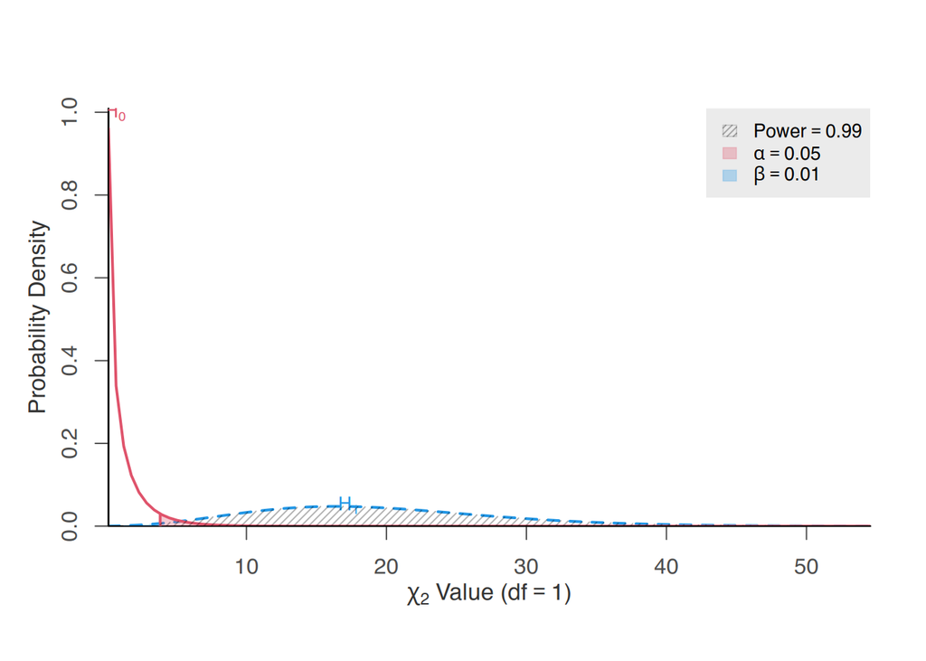

```
#> +--------------------------------------------------+
#> |                POWER CALCULATION                 |
#> +--------------------------------------------------+
#>
#> Generic Chi-square Test
#>
#> ----------------------------------------------------
#> Hypotheses
#> ----------------------------------------------------
#>   H0 (Null)        : lambda = null.lambda
#>   H1 (Alternative) : lambda > null.lambda
#>
#> ----------------------------------------------------
#> Results
#> ----------------------------------------------------
#>   Target NCP (lambda)  = 18.463 (vs. null.lambda = 0)
#>   Degrees of Freedom   = 1
#>   Type 1 Error (alpha) = 0.050
#>   Type 2 Error (beta)  = 0.010
#>   Statistical Power    = 0.990  <<
```

```r
power.chisq.test(ncp = 18.463,
                 df = 1,
                 alpha = 0.05,
                 plot = TRUE)
```

**Report**: The post-hoc power analysis indicated that a sample of 248 women provided a 0.99 probability of detecting the unique contribution of the number of induced abortions to infertility status, while controlling for other variables, assuming such a relationship exists in the population. The analysis was conducted using an $\alpha$ level of 0.05.

Given such a sample size and research design, minimum detectable test statistics (MDTS) is 7.849. The estimated value of 18.463 is much larger than the MDTS.

```r
power.chisq.test(ncp = NULL,    # calculate this
                 df = 1,        # degrees of freedom
                 power = 0.80,
                 alpha = 0.05,  # type 1 error rate
                 plot = FALSE)
```

```
#> +--------------------------------------------------+
#> |       MINIMUM DETECTABLE NCP CALCULATION         |
#> +--------------------------------------------------+
#>
#> Generic Chi-square Test
#>
#> ----------------------------------------------------
#> Hypotheses
#> ----------------------------------------------------
#>   H0 (Null)        : lambda = null.lambda
#>   H1 (Alternative) : lambda > null.lambda
#>
#> ----------------------------------------------------
#> Results
#> ----------------------------------------------------
#>   Target NCP (lambda)  = 7.849 (vs. null.lambda = 0)  <<
#>   Degrees of Freedom   = 1
#>   Type 1 Error (alpha) = 0.050
#>   Type 2 Error (beta)  = 0.200
#>   Statistical Power    = 0.800
```

## 1.5 Binomial Test

### 1.5.1 Post-Hoc

**Example**: The `faithful` dataset contains 272 observations of eruptions of the Old Faithful geyser in Yellowstone National Park. It includes:

- `eruptions`: Eruption duration (in minutes)
- `waiting`: Time between eruptions (in minutes)

We aim to test whether eruptions lasting more than 3 minutes occur more than half the time. What is the post-hoc power given the observed proportion and sample size?

```r
data(faithful)

long <- faithful$eruptions > 3
n.success <- sum(long)
n.total <- nrow(faithful)

binom.test(n.success, n.total, p = 0.50)
```

```
#>
#>  Exact binomial test
#>
#> data:  n.success and n.total
#> number of successes = 175, number of trials = 272, p-value = 2.609e-06
#> alternative hypothesis: true probability of success is not equal to 0.5
#> 95 percent confidence interval:
#>  0.5832982 0.7003038
#> sample estimates:
#> probability of success
#>              0.6433824
```

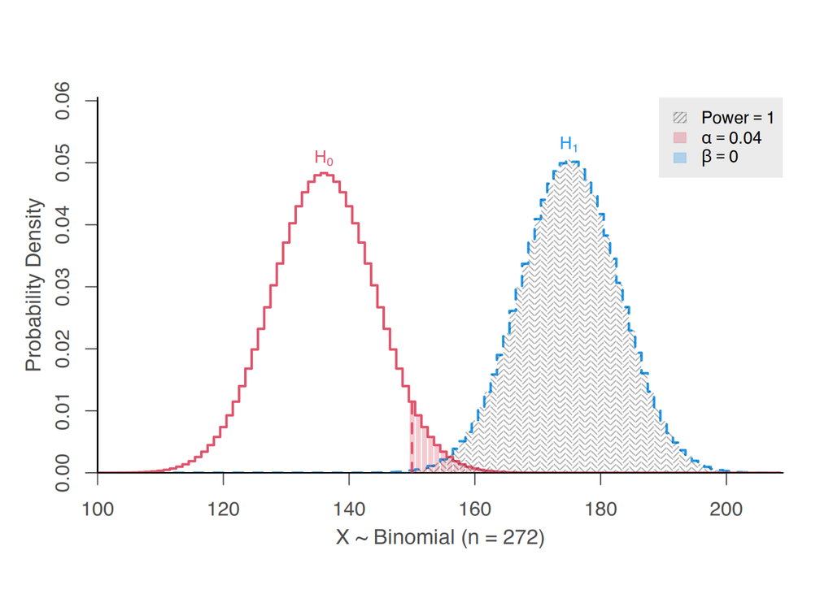

```
#> +--------------------------------------------------+
#> |                POWER CALCULATION                 |
#> +--------------------------------------------------+
#>
#> Generic Binomial Test
#>
#> ----------------------------------------------------
#> Hypotheses
#> ----------------------------------------------------
#>   H0 (Null)        : prob <= null.prob
#>   H1 (Alternative) : prob  > null.prob
#>
#> ----------------------------------------------------
#> Results
#> ----------------------------------------------------
#>   Target NCP (prob)    = 0.643 (vs. null.prob = 0.500)
#>   Number of Trials     = 272
#>   Type 1 Error (alpha) = 0.039
#>   Type 2 Error (beta)  = 0.001
#>   Statistical Power    = 0.999  <<
```

```r
power.binom.test(size = n.total,             # number of eruptions
                 prob = n.success / n.total, # prob. of occurrence under alt.
                 null.prob = 0.50,           # prob. of occurrence under null
                 alpha = 0.05,
                 alternative = "one.sided",
                 plot = TRUE)
```

**Report**: The post-hoc power analysis indicated that a sample of 272 eruptions provided a 0.999 probability of detecting whether eruptions lasting more than 3 minutes occur more than 50% of the time, if it exists in the underlying eruption pattern. The analysis was based on a one-sided test procedure with $\alpha$ = 0.05.

### 1.5.2 User-Defined Designs

**Example 1**: Find number of coin toss to test whether a coin is fair.

```r
power.binom.test(size = NULL,                 # number of tosses needed
                 prob = 0.50,                 # prob. of head under alt.
                 null.prob = c(0.495, 0.505), # equivalence margins
                 power = 0.80,
                 alpha = 0.05,                # type 1 error rate
                 alternative = "two.one.sided",
                 plot = FALSE)
```

```
#> +--------------------------------------------------+
#> |             SAMPLE SIZE CALCULATION              |
#> +--------------------------------------------------+
#>
#> Generic Binomial Test
#>
#> ----------------------------------------------------
#> Hypotheses
#> ----------------------------------------------------
#>   H0 (Null)        : prob <= min(null.prob) or
#>                      prob >= max(null.prob)
#>   H1 (Alternative) : prob  > min(null.prob) and
#>                      prob  < max(null.prob)
#>
#> ----------------------------------------------------
#> Results
#> ----------------------------------------------------
#>   Target NCP (prob)    = 0.500 (vs. null.prob = 0.495 and 0.505)
#>   Number of Trials     = 85826  <<
#>   Type 1 Error (alpha) = 0.050
#>   Type 2 Error (beta)  = 0.201
#>   Statistical Power    = 0.799
```

**Report 1**: Power analysis indicated that at least 85,826 coin tosses are required to determine whether a coin is fair. The analysis assumes a fair coin has a 0.50 probability of landing heads, with equivalence margins set at 0.495 and 0.505, using a two one-sided test procedure with $\alpha$ = 0.05.

**Example 2**: Find optimal number of replications in a Monte Carlo simulation.

To reliably detect a type 1 error rate of 0.05:

```r
power.binom.test(size = NULL,                 # number of replications needed
                 prob = 0.05,                 # prob. of falsely rejecting null
                 null.prob = c(0.045, 0.055), # equivalence margins
                 power = 0.80,
                 alpha = 0.05,
                 alternative = "two.one.sided",
                 plot = FALSE)
```

```
#> +--------------------------------------------------+
#> |             SAMPLE SIZE CALCULATION              |
#> +--------------------------------------------------+
#>
#> Generic Binomial Test
#>
#> ----------------------------------------------------
#> Hypotheses
#> ----------------------------------------------------
#>   H0 (Null)        : prob <= min(null.prob) or
#>                      prob >= max(null.prob)
#>   H1 (Alternative) : prob  > min(null.prob) and
#>                      prob  < max(null.prob)
#>
#> ----------------------------------------------------
#> Results
#> ----------------------------------------------------
#>   Target NCP (prob)    = 0.050 (vs. null.prob = 0.045 and 0.055)
#>   Number of Trials     = 16387  <<
#>   Type 1 Error (alpha) = 0.050
#>   Type 2 Error (beta)  = 0.198
#>   Statistical Power    = 0.802
```

To reliably detect a power rate of 0.80:

```r
power.binom.test(size = NULL,                 # number of replications needed
                 prob = 0.80,                 # prob. of correctly rejecting null
                 null.prob = c(0.795, 0.805), # equivalence margins
                 power = 0.80,
                 alpha = 0.05,
                 alternative = "two.one.sided",
                 plot = FALSE)
```

```
#> +--------------------------------------------------+
#> |             SAMPLE SIZE CALCULATION              |
#> +--------------------------------------------------+
#>
#> Generic Binomial Test
#>
#> ----------------------------------------------------
#> Hypotheses
#> ----------------------------------------------------
#>   H0 (Null)        : prob <= min(null.prob) or
#>                      prob >= max(null.prob)
#>   H1 (Alternative) : prob  > min(null.prob) and
#>                      prob  < max(null.prob)
#>
#> ----------------------------------------------------
#> Results
#> ----------------------------------------------------
#>   Target NCP (prob)    = 0.800 (vs. null.prob = 0.795 and 0.805)
#>   Number of Trials     = 55030  <<
#>   Type 1 Error (alpha) = 0.050
#>   Type 2 Error (beta)  = 0.199
#>   Statistical Power    = 0.801
```

**Report 2**: Power analysis indicated that at least 16,387 replications are required to estimate the Type 1 error rate at $\alpha$ = 0.05. This analysis used a two one-sided test procedure with equivalence margins set at 0.045 and 0.055. In contrast, at least 55,030 replications are needed to estimate statistical power at 0.80, assuming equivalence margins of 0.795 and 0.805, also using the two one-sided test procedure with $\alpha$ = 0.05.

## 1.6 Error Plots

`plot()` function (S3 method) is a wrapper around the generic functions above. It creates a visual representation of both null and alternative distributions, with shaded areas indicating Type 1 error (false positive) and Type 2 error (false negative) regions. Two-sided tests also report Type S and Type M errors.

Assign results of any `pwrss` function to an R object and pass it to the `plot()` function.

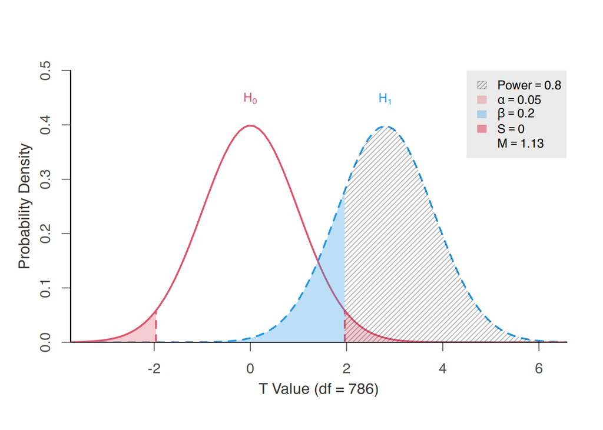

```r
power.t.student(d = 0.20, power = 0.80) |>
  plot()
```

NOTE: In earlier versions of the {pwrss} package, the `plot()` function generated multiple panel plots for ANCOVA designs and mediation models. This feature is no longer supported, as the updated functions now return one effect at a time.

# 2 Means (T-Test)

## 2.1 Independent Samples T-Test

An independent samples t-test is used to compare the mean outcomes of two groups that are statistically independent - meaning the outcome value of an individual in one group is not related to the outcome value of an individual in the other group. These groups may represent treatment and control conditions, gender groups (e.g., females and males), or any other pre-existing or experimentally assigned categories.

### 2.1.1 Parametric

**Example**: Suppose we aim to evaluate the extent to which a psychological intervention reduces post-earthquake psychosomatic symptoms. We consider a standardized mean difference as small as Cohen’s d = -0.20 between the treatment and control groups to be meaningful and relevant. What is the minimum required sample size per group, accounting for a 0.05 dropout rate in the treatment group?

```r
power.t.student(d = -0.20,
                power = 0.80,
                alpha = 0.05,
                alternative = "one.sided",
                design = "independent")
```

```
#> +--------------------------------------------------+
#> |             SAMPLE SIZE CALCULATION              |
#> +--------------------------------------------------+
#>
#> Student's T-Test (Independent Samples)
#>
#> ----------------------------------------------------
#> Hypotheses
#> ----------------------------------------------------
#>   H0 (Null)        : d - null.d >= 0
#>   H1 (Alternative) : d - null.d  < 0
#>
#> ----------------------------------------------------
#> Results
#> ----------------------------------------------------
#>   Effect Size (d)      = -0.200 (vs. null.d = 0)
#>   Sample Size          = 310 and 310  <<
#>   Type 1 Error (alpha) = 0.050
#>   Type 2 Error (beta)  = 0.200
#>   Statistical Power    = 0.800
```

```r
# account for attrition
inflate.sample(n = 310, rate = 0)    # control
```

```
#> 310
```

```r
inflate.sample(n = 310, rate = 0.05) # treatment
```

```
#> 327
```

**Report**: We conducted a power analysis to determine the required sample size for comparing treatment and control groups on psychosomatic symptoms. The analysis assumed a small effect size (Cohen’s d = 0.20), 0.80 statistical power, and a 0.05 significance level (one-tailed). Results indicated that 310 participants per group are needed (620 total). To account for an anticipated 0.05 attrition in the treatment group, an additional 17 participants are required, bringing the total sample size to 637.

### 2.1.2 Robust Parametric

Unlike experimental designs, group variances and population proportions may differ for some pre-existing groups (e.g. male and female teachers). Assume the smallest effect size of interest is Cohen’s d = 0.20. The expected variance ratio (female to male) is 1.5, and the prevalence ratio (female to male) in the population is 2. What is the minimum required sample size per group under these conditions?

```r
power.t.welch(d = 0.20,
              power = 0.80,
              n.ratio = 2,
              var.ratio = 1.5,
              alpha = 0.05,
              alternative = "two.sided")
```

```
#> +--------------------------------------------------+
#> |             SAMPLE SIZE CALCULATION              |
#> +--------------------------------------------------+
#>
#> Welch's T-Test (Independent Samples)
#>
#> ----------------------------------------------------
#> Hypotheses
#> ----------------------------------------------------
#>   H0 (Null)        : d - null.d  = 0
#>   H1 (Alternative) : d - null.d != 0
#>
#> ----------------------------------------------------
#> Results
#> ----------------------------------------------------
#>   Effect Size (d)      = 0.200 (vs. null.d = 0)
#>   Sample Size          = 518 and 259  <<
#>   Type 1 Error (alpha) = 0.050
#>   Type 2 Error (beta)  = 0.199
#>   Statistical Power    = 0.801
```

### 2.1.3 Non-Parametric

The outcome variable may be treated as continuous, but does not follow a normal distribution - for example, Likert-type scales with 5 to 7 categories, ranked data, or other bounded ordinal measures. Assume the smallest effect size of interest between the treatment and control groups is Cohen’s d = 0.20. What is the minimum required sample size per group, accounting for a 0.05 dropout rate in the treatment group?

```r
power.np.wilcoxon(d = 0.20,
                  power = 0.80,
                  n.ratio = 1,
                  alpha = 0.05,
                  alternative = "two.sided",
                  design = "independent",
                  distribution = "normal")
```

```
#> +--------------------------------------------------+
#> |             SAMPLE SIZE CALCULATION              |
#> +--------------------------------------------------+
#>
#> Wilcoxon Rank-Sum Test (Independent Samples)
#> (Wilcoxon-Mann-Whitney or Mann-Whitney U Test)
#>
#>   Method       : Guenther
#>   Distribution : Normal
#>
#> ----------------------------------------------------
#> Hypotheses
#> ----------------------------------------------------
#>   H0 (Null)        : d - null.d  = 0
#>   H1 (Alternative) : d - null.d != 0
#>
#> ----------------------------------------------------
#> Results
#> ----------------------------------------------------
#>   Effect Size (d)      = 0.200 (vs. null.d = 0)
#>   Sample Size          = 412 and 412  <<
#>   Type 1 Error (alpha) = 0.050
#>   Type 2 Error (beta)  = 0.200
#>   Statistical Power    = 0.800
```

```r
inflate.sample(n = 412, rate = 0.05) # treatment
```

```
#> 434
```

**Report**: We conducted a power analysis to determine the required sample size for comparing treatment and control groups on a Likert-type outcome measure, assuming that the observed categories reflect an underlying continuous latent construct that follows a normal distribution. The analysis assumed a small effect size (Cohen’s d = 0.20), 0.80 statistical power, and a 0.05 significance level (two-tailed). Results indicated that 412 participants per group are needed (824 total). To account for an anticipated 0.05 attrition in the treatment group, an additional 22 participants are required, bringing the total sample size to 846.

### 2.1.4 Non-Inferiority

A non-inferiority trial, which may evaluate the effectiveness of a new program, drug, or product, tests whether the mean outcome in the treatment group is not unacceptably worse than that in the conventional-treatment or placebo group, based on a pre-specified non-inferiority margin. For instance, a `d - null.d` difference as small as `margin = -0.05` may still support a conclusion of non-inferiority. What is the minimum required sample size to detect an effect size of d = 0.20 under this criterion?

When higher values of an outcome is better the margin usually takes NEGATIVE values; whereas when lower values of the outcome is better margin usually takes POSITIVE values.

```r
# parametric (an example report is provided below)
power.t.student(d = 0.20,
                margin = -0.05,
                power = 0.80,
                alpha = 0.05,
                alternative = "one.sided",
                design = "independent")
```

```
#> +--------------------------------------------------+
#> |             SAMPLE SIZE CALCULATION              |
#> +--------------------------------------------------+
#>
#> Student's T-Test (Independent Samples)
#>
#> ----------------------------------------------------
#> Hypotheses
#> ----------------------------------------------------
#>   H0 (Null)        : d - null.d <= margin
#>   H1 (Alternative) : d - null.d  > margin
#>
#> ----------------------------------------------------
#> Results
#> ----------------------------------------------------
#>   Effect Size (d)      = 0.200 (vs. null.d = 0)
#>   Sample Size          = 199 and 199  <<
#>   Type 1 Error (alpha) = 0.050
#>   Type 2 Error (beta)  = 0.199
#>   Statistical Power    = 0.801
```

```r
# consider 0.05 attrition rate
inflate.sample(n = 398, rate = 0.05)
```

```
#> 419
```

```r
# robust parametric
power.t.welch(d = 0.20,
              margin = -0.05,
              n.ratio = 2,
              var.ratio = 2,
              power = 0.80,
              alpha = 0.05,
              alternative = "one.sided")
```

```
#> +--------------------------------------------------+
#> |             SAMPLE SIZE CALCULATION              |
#> +--------------------------------------------------+
#>
#> Welch's T-Test (Independent Samples)
#>
#> ----------------------------------------------------
#> Hypotheses
#> ----------------------------------------------------
#>   H0 (Null)        : d - null.d <= margin
#>   H1 (Alternative) : d - null.d  > margin
#>
#> ----------------------------------------------------
#> Results
#> ----------------------------------------------------
#>   Effect Size (d)      = 0.200 (vs. null.d = 0)
#>   Sample Size          = 238 and 119  <<
#>   Type 1 Error (alpha) = 0.050
#>   Type 2 Error (beta)  = 0.200
#>   Statistical Power    = 0.800
```

```r
# non-parametric
power.np.wilcoxon(d = 0.20,
                  margin = -0.05,
                  power = 0.80,
                  alpha = 0.05,
                  alternative = "one.sided",
                  design = "independent")
```

```
#> +--------------------------------------------------+
#> |             SAMPLE SIZE CALCULATION              |
#> +--------------------------------------------------+
#>
#> Wilcoxon Rank-Sum Test (Independent Samples)
#> (Wilcoxon-Mann-Whitney or Mann-Whitney U Test)
#>
#>   Method       : Guenther
#>   Distribution : Normal
#>
#> ----------------------------------------------------
#> Hypotheses
#> ----------------------------------------------------
#>   H0 (Null)        : d - null.d <= margin
#>   H1 (Alternative) : d - null.d  > margin
#>
#> ----------------------------------------------------
#> Results
#> ----------------------------------------------------
#>   Effect Size (d)      = 0.200 (vs. null.d = 0)
#>   Sample Size          = 208 and 208  <<
#>   Type 1 Error (alpha) = 0.050
#>   Type 2 Error (beta)  = 0.199
#>   Statistical Power    = 0.801
```

**Report**: We conducted a power analysis to determine the required sample size for a non-inferiority trial comparing treatment and placebo groups. The analysis assumed a small treatment effect (d = 0.20), a non-inferiority margin of d = -0.05, 0.80 power, and a 0.05 significance level using a one-tailed test appropriate for non-inferiority designs. Results indicated that 199 participants per group (398 total) are needed to demonstrate that the treatment is not meaningfully inferior to the placebo. Accounting for an anticipated 0.05 attrition rate, we will recruit an additional 21 participants, yielding a target sample size of 419 participants.

### 2.1.5 Superiority

A superiority trial evaluates whether a new program, drug, or product leads to a meaningfully better mean outcome in the treatment group compared to a conventional treatment or placebo group, based on a pre-specified superiority margin. For example, a `d - null.d` difference as small as `margin = 0.05` may be considered sufficient to claim superiority. What is the minimum required sample size to detect an effect size of d = 0.20 under this criterion?

When higher values of an outcome is better margin usually takes POSITIVE values; whereas when lower values of the outcome is better margin usually takes NEGATIVE values.

```r
# parametric (an example report is provided below)
power.t.student(d = 0.20,
                margin = 0.05,
                power = 0.80,
                alpha = 0.05,
                alternative = "one.sided",
                design = "independent")
```

```
#> +--------------------------------------------------+
#> |             SAMPLE SIZE CALCULATION              |
#> +--------------------------------------------------+
#>
#> Student's T-Test (Independent Samples)
#>
#> ----------------------------------------------------
#> Hypotheses
#> ----------------------------------------------------
#>   H0 (Null)        : d - null.d <= margin
#>   H1 (Alternative) : d - null.d  > margin
#>
#> ----------------------------------------------------
#> Results
#> ----------------------------------------------------
#>   Effect Size (d)      = 0.200 (vs. null.d = 0)
#>   Sample Size          = 552 and 552  <<
#>   Type 1 Error (alpha) = 0.050
#>   Type 2 Error (beta)  = 0.199
#>   Statistical Power    = 0.801
```

```r
# consider 0.05 attrition rate
inflate.sample(n = 1104, rate = 0.05)
```

```
#> 1163
```

```r
# robust parametric
power.t.welch(d = 0.20,
              margin = 0.05,
              n.ratio = 2,
              var.ratio = 2,
              power = 0.80,
              alpha = 0.05,
              alternative = "one.sided")
```

```
#> +--------------------------------------------------+
#> |             SAMPLE SIZE CALCULATION              |
#> +--------------------------------------------------+
#>
#> Welch's T-Test (Independent Samples)
#>
#> ----------------------------------------------------
#> Hypotheses
#> ----------------------------------------------------
#>   H0 (Null)        : d - null.d <= margin
#>   H1 (Alternative) : d - null.d  > margin
#>
#> ----------------------------------------------------
#> Results
#> ----------------------------------------------------
#>   Effect Size (d)      = 0.200 (vs. null.d = 0)
#>   Sample Size          = 662 and 331  <<
#>   Type 1 Error (alpha) = 0.050
#>   Type 2 Error (beta)  = 0.200
#>   Statistical Power    = 0.800
```

```r
# non-parametric
power.np.wilcoxon(d = 0.20,
                  margin = 0.05,
                  power = 0.80,
                  alpha = 0.05,
                  alternative = "one.sided",
                  design = "independent")
```

```
#> +--------------------------------------------------+
#> |             SAMPLE SIZE CALCULATION              |
#> +--------------------------------------------------+
#>
#> Wilcoxon Rank-Sum Test (Independent Samples)
#> (Wilcoxon-Mann-Whitney or Mann-Whitney U Test)
#>
#>   Method       : Guenther
#>   Distribution : Normal
#>
#> ----------------------------------------------------
#> Hypotheses
#> ----------------------------------------------------
#>   H0 (Null)        : d - null.d <= margin
#>   H1 (Alternative) : d - null.d  > margin
#>
#> ----------------------------------------------------
#> Results
#> ----------------------------------------------------
#>   Effect Size (d)      = 0.200 (vs. null.d = 0)
#>   Sample Size          = 578 and 578  <<
#>   Type 1 Error (alpha) = 0.050
#>   Type 2 Error (beta)  = 0.199
#>   Statistical Power    = 0.801
```

**Report**: We conducted a power analysis to determine the required sample size for a superiority trial comparing treatment and placebo groups. The analysis assumed a small treatment effect (d = 0.20), a superiority margin of d = 0.05, 0.80 power, and a 0.05 significance level using a one-tailed test appropriate for superiority designs. Results indicated that 552 participants per group (1104 total) are needed to demonstrate that the treatment is meaningfully superior to the placebo. Accounting for an anticipated 0.05 attrition rate in both groups, we will recruit an additional 59 participants, yielding a target sample size of 1163 participants.

### 2.1.6 Equivalence

```r
# parametric (an example report is provided below)
power.t.student(d = 0,
                margin = c(-0.10, 0.10),
                power = 0.80,
                alpha = 0.05,
                alternative = "two.one.sided",
                design = "independent")
```

```
#> +--------------------------------------------------+
#> |             SAMPLE SIZE CALCULATION              |
#> +--------------------------------------------------+
#>
#> Student's T-Test (Independent Samples)
#>
#> ----------------------------------------------------
#> Hypotheses
#> ----------------------------------------------------
#>   H0 (Null)        : d - null.d <= min(margin) or
#>                      d - null.d >= max(margin)
#>   H1 (Alternative) : d - null.d  > min(margin) and
#>                      d - null.d  < max(margin)
#>
#> ----------------------------------------------------
#> Results
#> ----------------------------------------------------
#>   Effect Size (d)      = 0 (vs. null.d = 0)
#>   Sample Size          = 1714 and 1714  <<
#>   Type 1 Error (alpha) = 0.050
#>   Type 2 Error (beta)  = 0.200
#>   Statistical Power    = 0.800
```

```r
# consider 0.05 attrition rate
inflate.sample(n = 3428, rate = 0.05)
```

```
#> 3609
```

```r
# robust parametric
power.t.welch(d = 0,
              margin = c(-0.10, 0.10),
              n.ratio = 2,
              var.ratio = 2,
              power = 0.80,
              alpha = 0.05,
              alternative = "two.one.sided")
```

```
#> +--------------------------------------------------+
#> |             SAMPLE SIZE CALCULATION              |
#> +--------------------------------------------------+
#>
#> Welch's T-Test (Independent Samples)
#>
#> ----------------------------------------------------
#> Hypotheses
#> ----------------------------------------------------
#>   H0 (Null)        : d - null.d <= min(margin) or
#>                      d - null.d >= max(margin)
#>   H1 (Alternative) : d - null.d  > min(margin) and
#>                      d - null.d  < max(margin)
#>
#> ----------------------------------------------------
#> Results
#> ----------------------------------------------------
#>   Effect Size (d)      = 0 (vs. null.d = 0)
#>   Sample Size          = 2056 and 1028  <<
#>   Type 1 Error (alpha) = 0.050
#>   Type 2 Error (beta)  = 0.200
#>   Statistical Power    = 0.800
```

```r
# non-parametric
power.np.wilcoxon(d = 0,
                  margin = c(-0.10, 0.10),
                  power = 0.80,
                  alpha = 0.05,
                  alternative = "two.one.sided",
                  design = "independent")
```

[output not shown]

**Report**: We conducted a power analysis to determine the required sample size for an equivalence trial comparing a new treatment to a conventional one. The analysis assumed no difference (d = 0), an equivalence margin ranging from d = -0.10 to d = 0.10, 0.80 power, and a 0.05 significance level using a two one-sided test appropriate for equivalence designs. Results indicated that 1714 participants per group (3428 total) are needed to demonstrate that the new treatment is similar to the conventional one. Accounting for an anticipated 0.05 attrition rate in both groups, we will recruit an additional 181 participants, yielding a target sample size of 3609 participants.

### 2.1.7 Minimum Effect

Minimum effect testing is useful when the goal is to assess whether a new program, drug, or product performs meaningfully better or worse than a conventional treatment-beyond a pre-defined threshold of practical significance (equivalence margins). For instance, a difference of `d - null.d` falling outside the range `margin = c(-0.05, 0.05)` may be sufficient to conclude that the intervention is either inferior or superior, exceeding the bounds of minimal practical importance. What is the minimum required sample size to detect an effect size of Cohen’s d = 0.20 under this criterion?

```r
# parametric (an example report is provided below)
power.t.student(d = 0.20,
                margin = c(-0.05, 0.05),
                power = 0.80,
                alpha = 0.05,
                alternative = "two.one.sided",
                design = "independent")
```

```
#> +--------------------------------------------------+
#> |             SAMPLE SIZE CALCULATION              |
#> +--------------------------------------------------+
#>
#> Student's T-Test (Independent Samples)
#>
#> ----------------------------------------------------
#> Hypotheses
#> ----------------------------------------------------
#>   H0 (Null)        : d - null.d >= min(margin) and
#>                      d - null.d <= max(margin)
#>   H1 (Alternative) : d - null.d  < min(margin) or
#>                      d - null.d  > max(margin)
#>
#> ----------------------------------------------------
#> Results
#> ----------------------------------------------------
#>   Effect Size (d)      = 0.200 (vs. null.d = 0)
#>   Sample Size          = 700 and 700  <<
#>   Type 1 Error (alpha) = 0.050
#>   Type 2 Error (beta)  = 0.200
#>   Statistical Power    = 0.800
```

```r
# consider 0.05 attrition rate
inflate.sample(n = 1400, rate = 0.05)
```

```
#> 1474
```

```r
# robust parametric
power.t.welch(d = 0.20,
              margin = c(-0.05, 0.05),
              n.ratio = 2,
              var.ratio = 2,
              power = 0.80,
              alpha = 0.05,
              alternative = "two.one.sided")
```

```
#> +--------------------------------------------------+
#> |             SAMPLE SIZE CALCULATION              |
#> +--------------------------------------------------+
#>
#> Welch's T-Test (Independent Samples)
#>
#> ----------------------------------------------------
#> Hypotheses
#> ----------------------------------------------------
#>   H0 (Null)        : d - null.d >= min(margin) and
#>                      d - null.d <= max(margin)
#>   H1 (Alternative) : d - null.d  < min(margin) or
#>                      d - null.d  > max(margin)
#>
#> ----------------------------------------------------
#> Results
#> ----------------------------------------------------
#>   Effect Size (d)      = 0.200 (vs. null.d = 0)
#>   Sample Size          = 842 and 421  <<
#>   Type 1 Error (alpha) = 0.050
#>   Type 2 Error (beta)  = 0.199
#>   Statistical Power    = 0.801
```

```r
# non-parametric
power.np.wilcoxon(d = 0.20,
                  margin = c(-0.05, 0.05),
                  power = 0.80,
                  alpha = 0.05,
                  alternative = "two.one.sided",
                  design = "independent")
```

```
#> +--------------------------------------------------+
#> |             SAMPLE SIZE CALCULATION              |
#> +--------------------------------------------------+
#>
#> Wilcoxon Rank-Sum Test (Independent Samples)
#> (Wilcoxon-Mann-Whitney or Mann-Whitney U Test)
#>
#>   Method       : Guenther
#>   Distribution : Normal
#>
#> ----------------------------------------------------
#> Hypotheses
#> ----------------------------------------------------
#>   H0 (Null)        : d - null.d >= min(margin) and
#>                      d - null.d <= max(margin)
#>   H1 (Alternative) : d - null.d  < min(margin) or
#>                      d - null.d  > max(margin)
#>
#> ----------------------------------------------------
#> Results
#> ----------------------------------------------------
#>   Effect Size (d)      = 0.200 (vs. null.d = 0)
#>   Sample Size          = 733 and 733  <<
#>   Type 1 Error (alpha) = 0.050
#>   Type 2 Error (beta)  = 0.200
#>   Statistical Power    = 0.800
```

**Report**: We conducted a power analysis to determine the required sample size for minimum effect testing comparing a new treatment to a conventional one. The analysis assumed a modest difference (d = 0.20), an equivalence margin ranging from d = -0.05 to d = 0.05, 0.80 power, and a 0.05 significance level using a two one-sided test appropriate for minimum effect testing. Results indicated that 700 participants per group (1400 total) are needed to reliably detect whether the new treatment differs from the conventional treatment by more than the minimally important difference. Accounting for an anticipated 0.05 attrition rate in both groups, we will recruit an additional 74 participants, yielding a target sample size of 1474 participants.

## 2.2 Paired Samples T-Test

A paired samples t-test is used to compare the mean outcomes of two related or matched groups, where each observation in one group is paired with a corresponding observation in the other. This test is appropriate when the outcome values are not independent, such as when measurements are taken from the same individuals at two time points (e.g., pre-test and post-test), or when individuals are matched based on characteristics (e.g., siblings, matched pairs in experimental designs).

### 2.2.1 Parametric

**Example**: A mental health clinic transitions from in-person to online-only group therapy sessions due to logistical constraints. To evaluate whether the new format supports a core therapeutic outcome - emotional regulation - researchers plan to recruit a new group of clients participating in online therapy and compare their outcomes to a historical sample of clients who previously completed the same program in person. Participants will be matched based on baseline symptom severity, age, gender, and diagnosis. The primary outcome is emotional regulation, assessed at the end of the program using the Difficulties in Emotion Regulation Scale (DERS). A two-sided test will be conducted to determine whether emotional regulation improves or deteriorates in the online format in comparison to the in-person format. Researchers aim to detect a small effect (d = 0.20), using a two-sided test with $\alpha$ = 0.05 and 0.80 power. What is the minimum required sample size under this criterion?

```r
power.t.student(d = 0.20,
                power = 0.80,
                alpha = 0.05,
                alternative = "two.sided",
                design = "paired")
```

```
#> +--------------------------------------------------+
#> |             SAMPLE SIZE CALCULATION              |
#> +--------------------------------------------------+
#>
#> Student's T-Test (Paired Samples)
#>
#> ----------------------------------------------------
#> Hypotheses
#> ----------------------------------------------------
#>   H0 (Null)        : d - null.d  = 0
#>   H1 (Alternative) : d - null.d != 0
#>
#> ----------------------------------------------------
#> Results
#> ----------------------------------------------------
#>   Effect Size (d)      = 0.200 (vs. null.d = 0)
#>   Sample Size          = 199  <<
#>   Type 1 Error (alpha) = 0.050
#>   Type 2 Error (beta)  = 0.198
#>   Statistical Power    = 0.802
```

```r
# consider an attrition rate of 0.05
inflate.sample(n = 199, rate = 0.05)
```

```
#> 210
```

**Report**: We conducted a power analysis to determine the required sample size for comparing emotional regulation scores in online versus in-person therapy sessions. The analysis assumed a modest difference between groups (d = 0.20), 0.80 power, and a 0.05 significance level using a two-sided test. Results indicated that 199 participants will need to be matched to reliably determine whether online therapy is better or worse than in-person therapy. Accounting for an anticipated 0.05 attrition in the online group, an additional 11 participants need to be matched, yielding a target sample size of 210 participants.

### 2.2.2 Non-parametric

**Example**: Consider the earlier example, but now with a focus on a different outcome: session satisfaction ratings, measured on a 5-point scale (1 = Not at all, 5 = Extremely). Researchers aim to determine whether satisfaction ratings differ between the online and in-person formats. To test this, they plan to use the Wilcoxon signed-rank test for paired data, targeting a small effect size (d = 0.20) with a two-sided significance level of $\alpha$ = 0.05. What is the minimum required sample size under these conditions?

```r
power.np.wilcoxon(d = 0.20,
                  power = 0.80,
                  alpha = 0.05,
                  alternative = "two.sided",
                  design = "paired",
                  distribution = "normal")
```

```
#> +--------------------------------------------------+
#> |             SAMPLE SIZE CALCULATION              |
#> +--------------------------------------------------+
#>
#> Wilcoxon Signed-Rank Test (Paired Samples)
#>
#>   Method       : Guenther
#>   Distribution : Normal
#>
#> ----------------------------------------------------
#> Hypotheses
#> ----------------------------------------------------
#>   H0 (Null)        : d - null.d  = 0
#>   H1 (Alternative) : d - null.d != 0
#>
#> ----------------------------------------------------
#> Results
#> ----------------------------------------------------
#>   Effect Size (d)      = 0.200 (vs. null.d = 0)
#>   Sample Size          = 208  <<
#>   Type 1 Error (alpha) = 0.050
#>   Type 2 Error (beta)  = 0.199
#>   Statistical Power    = 0.801
```

```r
# consider an attrition rate of 0.05
inflate.sample(n = 208, rate = 0.05)
```

```
#> 219
```

**Report**: We conducted a power analysis to determine the required sample size for comparing session satisfaction ratings in online versus in-person therapy sessions using Wilcoxon signed-rank test. The analysis assumed a modest difference between groups (d = 0.20), 0.80 power, a 0.05 significance level using a two-sided test, and normal distribution. Results indicated that 208 participants will need to be matched to reliably determine whether online therapy is better or worse than in-person therapy in terms of session satisfaction ratings. Accounting for an anticipated 0.05 attrition in the online group, an additional 11 participants need to be matched, yielding a target sample size of 219 participants.

### 2.2.3 Non-inferiority

Consider the earlier example, but now with a focus on a different outcome: perceived group cohesion. To evaluate whether the new format preserves the perceived group cohesion, researchers plan to conduct a non-inferiority test to assess whether perceived group cohesion ratings in the online group is not meaningfully worse than that of the matched in-person group. The researcher expects no change (`d = 0`). The `d - null.d` difference can be as small as `margin = -0.10` but the online format will still be considered as non-inferior. What is the minimum required sample size under this criterion?

When higher values of an outcome is better the margin usually takes NEGATIVE values; whereas when lower values of the outcome is better margin usually takes POSITIVE values.

```r
# parametric (an example report is provided below)
power.t.student(d = 0,
                margin = -0.10,
                power = 0.80,
                alpha = 0.05,
                alternative = "one.sided",
                design = "paired")
```

```
#> +--------------------------------------------------+
#> |             SAMPLE SIZE CALCULATION              |
#> +--------------------------------------------------+
#>
#> Student's T-Test (Paired Samples)
#>
#> ----------------------------------------------------
#> Hypotheses
#> ----------------------------------------------------
#>   H0 (Null)        : d - null.d <= margin
#>   H1 (Alternative) : d - null.d  > margin
#>
#> ----------------------------------------------------
#> Results
#> ----------------------------------------------------
#>   Effect Size (d)      = 0 (vs. null.d = 0)
#>   Sample Size          = 619  <<
#>   Type 1 Error (alpha) = 0.050
#>   Type 2 Error (beta)  = 0.200
#>   Statistical Power    = 0.800
```

```r
# consider 0.05 attrition rate
inflate.sample(n = 619, rate = 0.05)
```

```
#> 652
```

```r
# non-parametric
power.np.wilcoxon(d = 0,
                  margin = -0.10,
                  power = 0.80,
                  alpha = 0.05,
                  alternative = "one.sided",
                  design = "paired")
```

```
#> +--------------------------------------------------+
#> |             SAMPLE SIZE CALCULATION              |
#> +--------------------------------------------------+
#>
#> Wilcoxon Signed-Rank Test (Paired Samples)
#>
#>   Method       : Guenther
#>   Distribution : Normal
#>
#> ----------------------------------------------------
#> Hypotheses
#> ----------------------------------------------------
#>   H0 (Null)        : d - null.d <= margin
#>   H1 (Alternative) : d - null.d  > margin
#>
#> ----------------------------------------------------
#> Results
#> ----------------------------------------------------
#>   Effect Size (d)      = 0 (vs. null.d = 0)
#>   Sample Size          = 648  <<
#>   Type 1 Error (alpha) = 0.050
#>   Type 2 Error (beta)  = 0.200
#>   Statistical Power    = 0.800
```

**Report**: We conducted a power analysis to determine the required sample size for a non-inferiority test comparing perceived group cohesion ratings in online versus in-person therapy sessions. The analysis assumed no true difference between groups (d = 0), a non-inferiority margin of -0.10, 0.80 power, and a 0.05 significance level using a one-sided test appropriate for non-inferiority designs. Results indicated that 619 participants will need to be matched to reliably determine whether online therapy is not meaningfully worse than in-person therapy by more than the pre-specified margin. Accounting for an anticipated 0.05 attrition in the online group, an additional 33 participants are required, yielding a target sample size of 652 participants.

### 2.2.4 Superiority

Consider the earlier example, but now with a focus on a different outcome: psychological safety. While maintaining core therapeutic outcomes is important, the online format may offer additional advantages. One such outcome is psychological safety, which is defined as the comfort in expressing thoughts, emotions, and personal experiences during group sessions without fear of judgment or rejection. To evaluate whether the online format enhances this dimension, researchers plan to recruit a new group of clients beginning online therapy and match them to a historical sample of previous clients who completed the same program in person. Matching is done based on baseline symptom severity, age, gender, and diagnosis.

A superiority test is conducted to assess whether psychological safety ratings are meaningfully higher in the online group compared to the matched in-person group. The researcher is interested in a modest change (`d = 0.20`), and `d - null.d` difference can be as small as `margin = 0.10` but the online format will still be considered as superior. What is the minimum required sample size under this criterion?

When higher values of an outcome is better margin usually takes POSITIVE values; whereas when lower values of the outcome is better margin usually takes NEGATIVE values.

```r
# parametric (an example report is provided below)
power.t.student(d = 0.20,
                margin = 0.10,
                power = 0.80,
                alpha = 0.05,
                alternative = "one.sided",
                design = "paired")
```

[output not shown]

```
#> +--------------------------------------------------+
#> |             SAMPLE SIZE CALCULATION              |
#> +--------------------------------------------------+
#>
#> Student's T-Test (Paired Samples)
#>
#> ----------------------------------------------------
#> Hypotheses
#> ----------------------------------------------------
#>   H0 (Null)        : d - null.d <= margin
#>   H1 (Alternative) : d - null.d  > margin
#>
#> ----------------------------------------------------
#> Results
#> ----------------------------------------------------
#>   Effect Size (d)      = 0.200 (vs. null.d = 0)
#>   Sample Size          = 627  <<
#>   Type 1 Error (alpha) = 0.050
#>   Type 2 Error (beta)  = 0.200
#>   Statistical Power    = 0.800
```

```r
# consider 0.05 attrition rate
inflate.sample(n = 627, rate = 0.05)
```

```
#> 660
```

```r
# non-parametric
power.np.wilcoxon(d = 0.20,
                  margin = 0.10,
                  power = 0.80,
                  alpha = 0.05,
                  alternative = "one.sided",
                  design = "paired")
```

```
#> +--------------------------------------------------+
#> |             SAMPLE SIZE CALCULATION              |
#> +--------------------------------------------------+
#>
#> Wilcoxon Signed-Rank Test (Paired Samples)
#>
#>   Method       : Guenther
#>   Distribution : Normal
#>
#> ----------------------------------------------------
#> Hypotheses
#> ----------------------------------------------------
#>   H0 (Null)        : d - null.d <= margin
#>   H1 (Alternative) : d - null.d  > margin
#>
#> ----------------------------------------------------
#> Results
#> ----------------------------------------------------
#>   Effect Size (d)      = 0.200 (vs. null.d = 0)
#>   Sample Size          = 657  <<
#>   Type 1 Error (alpha) = 0.050
#>   Type 2 Error (beta)  = 0.200
#>   Statistical Power    = 0.800
```

### 2.2.5 Equivalence

**Example**: Consider the earlier example, but now with a focus on a different outcome: emotional intensity. While the new format is expected to retain key therapeutic benefits, certain outcomes must remain stable for the intervention to be considered acceptable. One such outcome is emotional intensity during sessions, defined as the typical depth and strength of emotions experienced and expressed by participants in group discussions. Too little emotional intensity may signal disengagement or superficial participation, while too much may overwhelm participants or disrupt group cohesion. Therefore, maintaining a similar level of emotional intensity in the online format is essential. To evaluate this, researchers plan to recruit a new group of clients beginning online therapy and match them to a historical sample of previous clients who completed the same program in person. Matching is done based on baseline symptom severity, age, gender, and diagnosis.

An equivalence test will be conducted to assess whether emotional intensity scores in the online group are meaningfully similar to those in the matched in-person group. The researcher is interested in detecting no difference (d = 0). The `d - null.d` difference within the range `margin = c(-0.10, 0.10)` is considered sufficient to claim equivalence. What is the minimum required sample size under this criterion?

```r
# parametric (an example report is provided below)
power.t.student(d = 0,
                margin = c(-0.10, 0.10),
                power = 0.80,
                alpha = 0.05,
                alternative = "two.one.sided",
                design = "paired")
```

```
#> +--------------------------------------------------+
#> |             SAMPLE SIZE CALCULATION              |
#> +--------------------------------------------------+
#>
#> Student's T-Test (Paired Samples)
#>
#> ----------------------------------------------------
#> Hypotheses
#> ----------------------------------------------------
#>   H0 (Null)        : d - null.d <= min(margin) or
#>                      d - null.d >= max(margin)
#>   H1 (Alternative) : d - null.d  > min(margin) and
#>                      d - null.d  < max(margin)
#>
#> ----------------------------------------------------
#> Results
#> ----------------------------------------------------
#>   Effect Size (d)      = 0 (vs. null.d = 0)
#>   Sample Size          = 858  <<
#>   Type 1 Error (alpha) = 0.050
#>   Type 2 Error (beta)  = 0.200
#>   Statistical Power    = 0.800
```

```r
# consider 0.05 attrition rate
inflate.sample(n = 858, rate = 0.05)
```

```
#> 904
```

```r
# non-parametric
power.np.wilcoxon(d = 0,
                  margin = c(-0.10, 0.10),
                  power = 0.80,
                  alpha = 0.05,
                  alternative = "two.one.sided",
                  design = "paired")
```

[output not shown]

**Report**: We conducted a power analysis to determine the required sample size for an equivalence test comparing emotional intensity during online versus in-person group therapy sessions. The analysis assumed no difference between groups (d = 0), an equivalence margin of -0.10 and 0.10, 0.80 power, and a 0.05 significance level using a two one-sided test appropriate for equivalence designs. Results indicated that 858 participants will need to be matched to reliably determine whether emotional intensity in online therapy is meaningfully similar to that in in-person therapy within the pre-specified equivalence margin. Accounting for an anticipated 0.05 attrition in the online group, an additional 46 participants are required, yielding a target sample size of 904 participants.